# Telecom company data analysis and churn prediction

## TABLE OF CONTENT:

- Introduction;
- Getting and cleaning data;
- Feature engineering;
- Exploratory data analysis;
- Modeling;
- Conclusion;

## Introduction

*The churn rate, also known as the rate of attrition, is the percentage of subscribers to a service who discontinue their subscriptions to that service within a given time period. For a company to expand its clientele, its growth rate, as measured by the number of new customers, must exceed its churn rate. The rate is generally expressed as a percentage.* (https://www.investopedia.com)

The goal of this project is to improve skills in data analysis and R programming language, while trying to identify and understand customer churning trends in telecom company data set. Main guidelines:

- Keep it simple.
- Make it fun.

Data: https://www.kaggle.com/hkalsi/telecom-company-customer-churn

Code: https://github.com/km1414/Kaggle/tree/master/churn-prediction

## Getting and cleaning data (1)

### Download data

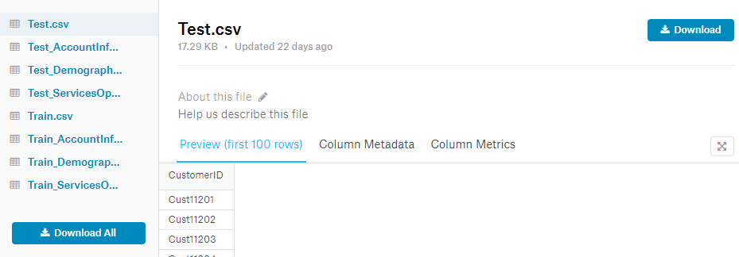

### Main libraries

`data.table`

`tidyverse (dplyr, ggplot2, tidyr, lubridate)`

`caret`

## Getting and cleaning data (2)

### Read and join data

- Only train set used.
- Data documentation denotes missing values in data set: `'', '?', 'MISSINGVAL', 'NA'`
- Different format: 3 files - wide, 1 file - long.

### Inspect data

- 5298 observations, 25 variables (21 - `character` variables, 4 - `numeric` variables).
- 4 variable groups: **demographics info** (gender, education, etc.), **account info** (contact type, charges, etc.), **service details** (streaming tv, online security, etc.), **churn**.
- Missing values:

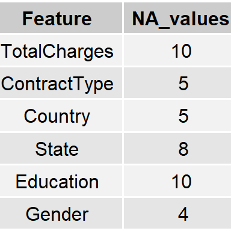

## Getting and cleaning data (3)

### Solve NA values

- TotalCharges - drop 10 observations (new users, didn't pay yet).
- Contract type - drop 5 observations (couldn't fill, important variable).
- Country - drop variable (same value over whole data set).
- State - drop variable (same value over whole data set).
- Education - set NA values to `Other`.
- Gender - fill NA values with most frequent value (low significance variable).

### Tidy other variables

- Dates converted from `character` to `date`.
- Service variables standartized to have `Yes` and `No` levels.

## Feature engineering

### Editing features

- New variable - **MonthsSinceEntry** = (Date of data collection - Date of customer entry) / 30
- New variable - **PaymentLevel** = Total charges paid / Months since entry / Base cahrge - 1
- New variable - **ServiceType** = `Phone` or `Internet` or `Phone and Internet`.
- New variable - **AdditionalServices** = Count of additional services ordered (from different columns).
- Drop used date variables.
- Drop observations with extreme outliers (probably errors).
- Convert all `character` variables to `factor`.

### Data preview after cleaning

- 5278 observations, 23 variables (18 - `factor` variables, 5 - `numeric` variables).
- No missing values.

## Exploratory data analysis (1)

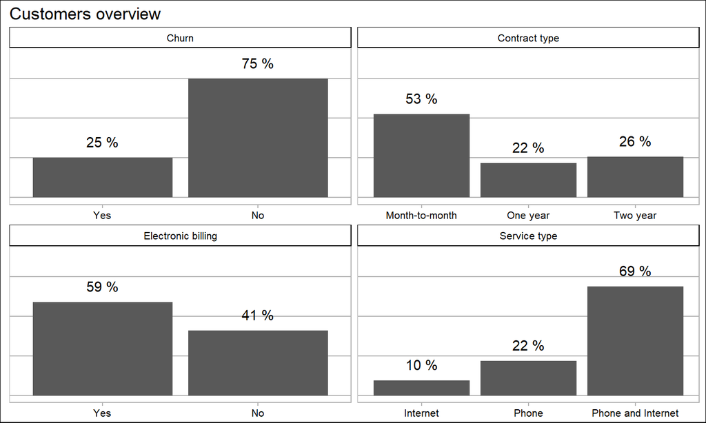

Bigest part of customers have month-to-month contract type and has opportunity to churn any time. Most popular service type - phone and internet, electronic billing is more popular than classic billing. Churn rate reaches quarter of customers.

## Exploratory data analysis (2)

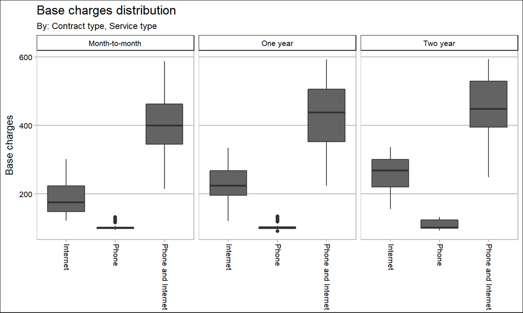

Base charges slightly differ between different contract types because of additional services selected. No important outliers found.

## Exploratory data analysis (3)

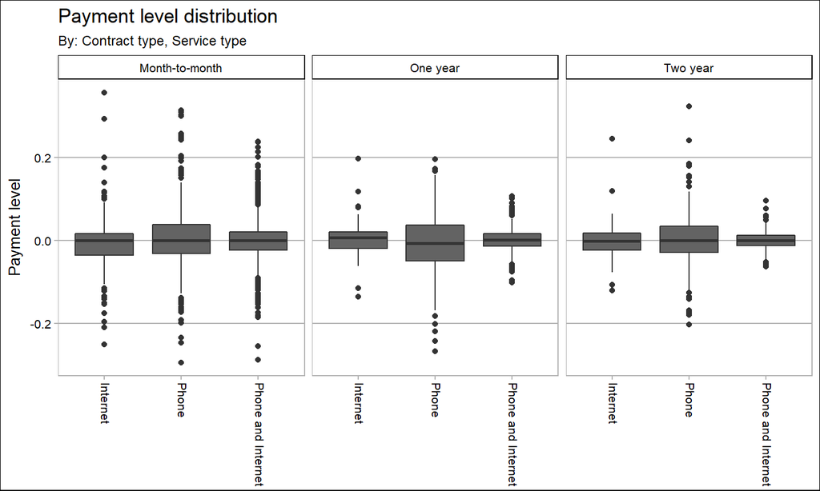

Phone service type has highest variance, but all distributions look similar. Payment level outliers weren't removed (except extreme outliers), because it could be significant churn indicator.

## Exploratory data analysis (4)

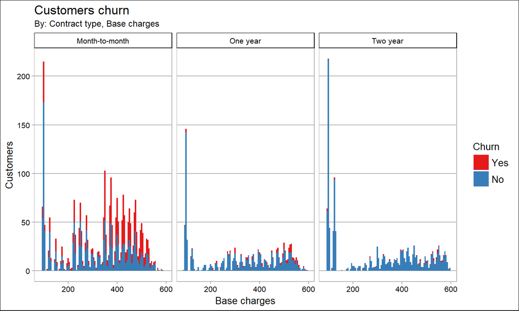

Month-to-month contract type has bigest part of customers and highest churn rate (41%). Two year contracts have lowest churn rate (3%), and one year contracts have 11% churn rate.

## Exploratory data analysis (5)

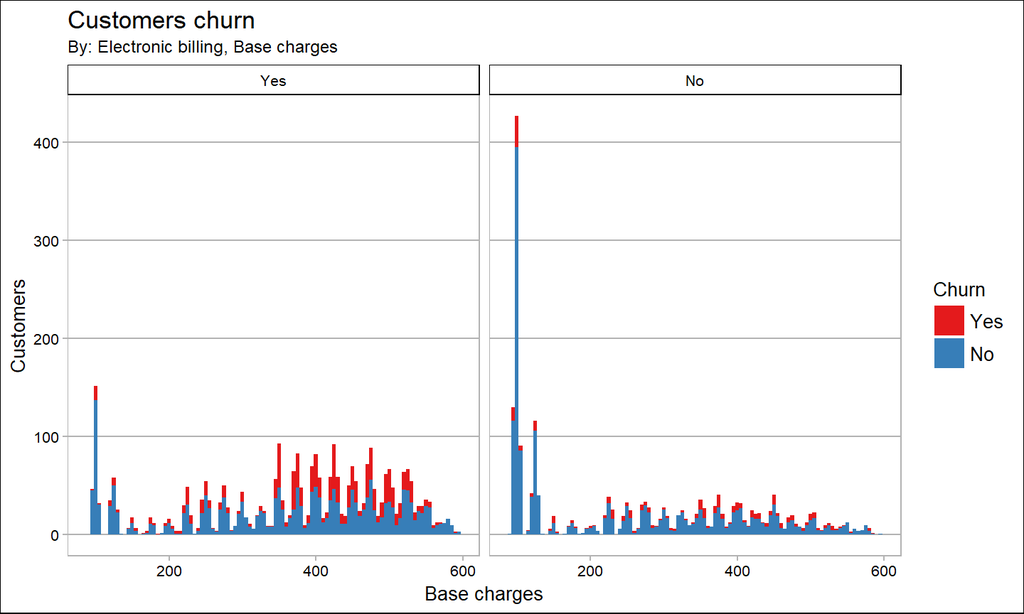

Electronic billing method includes more customers and higher churn rate among electronic billing users is higher (32% vs. 15%).

## Exploratory data analysis (6)

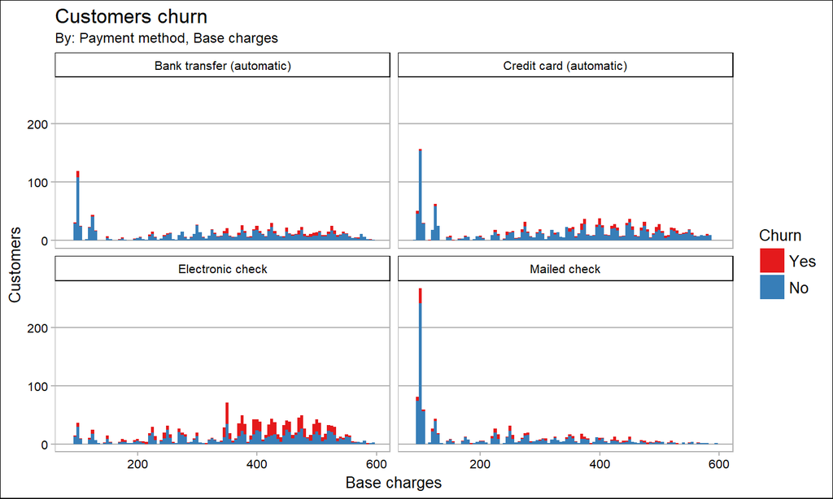

Churn rate is also different in customer groups by payment method. Bank transfer (automatic) users have 17% churn rate, Credit card (automatic) - 16% Electronic check - 44% (the bigest rate), Mailed check - 18%.

## Exploratory data analysis (7)

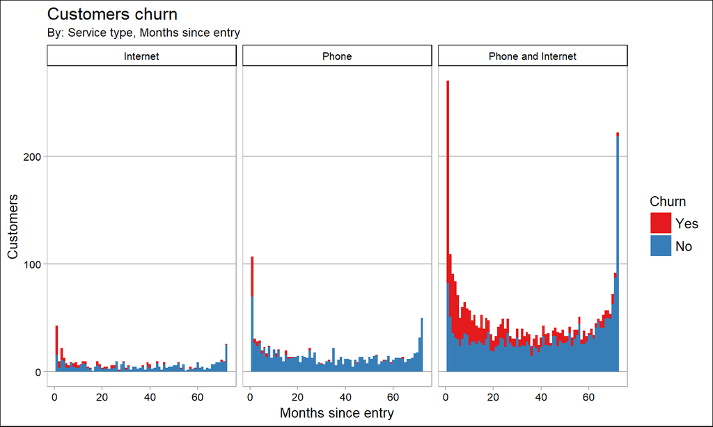

Churn rate, compared between different service types, shows 22% rate in only internet users group, 7% in phone users group and 31% in phone and internet users group. This group alse has bigest number of customers.

## Exploratory data analysis (8)

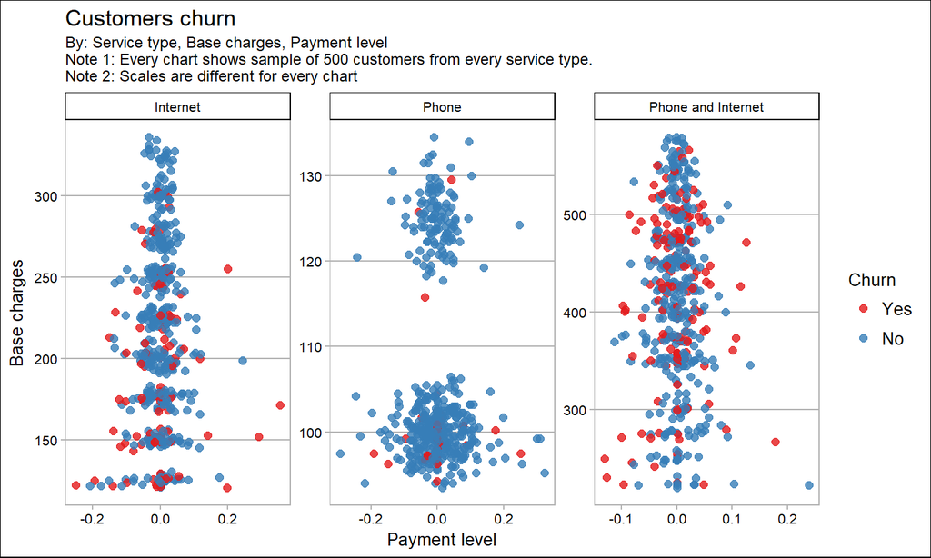

Customers could be clustered into groups by service plan base charges, but payment level doesn't show obviuos dependencies.

## Exploratory data analysis (9)

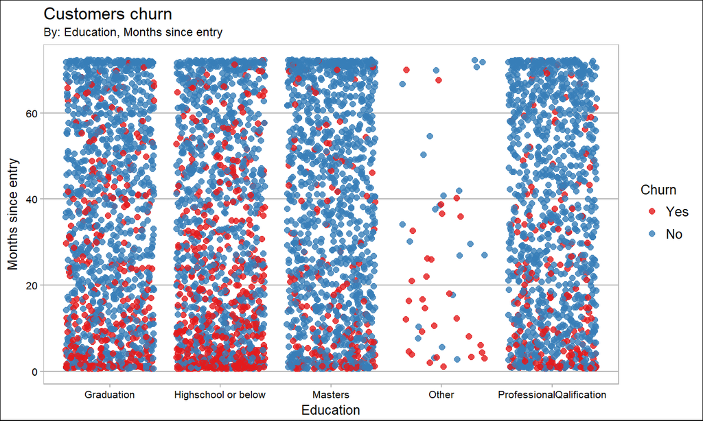

Biggest churn rate in standart education categories is in **Graduation** and **Highschool or below** groups (26% and 39%). Small group **Other** has 57%, **Masters** - 15%, **Professional Qalification** - 17%. Biggest part of customers entered at the start of data collection.

## Exploratory data analysis (10)

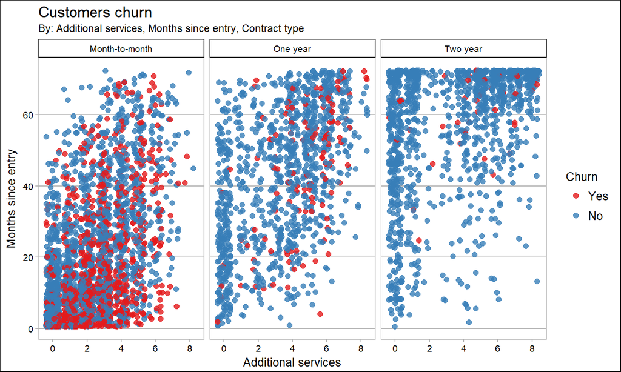

Customers group with highest churning rate are users, entered in last 2-3 years, also have 4 or less additional services. Customers with two year contracts usually are older, have more additional services and very low churn rate.

## Exploratory data analysis (11)

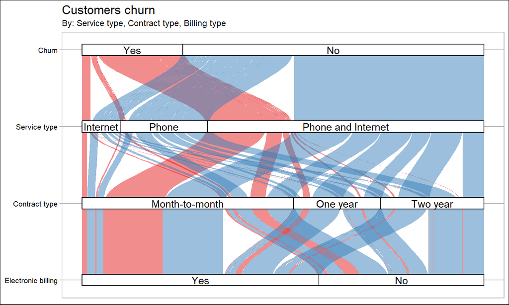

Customer target group could be seen as a strong red line. They are Phone and internet users, have month-to-month contract type and use electronic billing.

## Exploratory data analysis (12)

### Identify high risk - target group

- Contract type - **Month-to-month**
- ServiceType - **Phone and Internet**
- ElectronicBilling - **Yes**
- Payment method - **Electronic check**
- Months since entry - **< 36**
- Base charges - **> 250**

More conditions could be added to make group smaller.

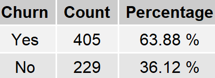

The task is to convert these customers from potential churners into users with long term contracts.

## Modeling (1)

**Preprocessing**

- Convert `factor` variables to `one-hot encoded` variables.
- Split data into Train and Test sets (80/20).

**Modeling**

- Scaling, PCA, 5 fold - cross validation, hyper-parameter tuning, metric - AUC (area under curve).
- Algorithms:
  - Logistic regression (caret)
  - Decision trees (caret)
  - Random forest (caret)
  - Support Vector Machines with Linear Kernel (caret)
  - Support Vector Machines with Radial Basis Function Kernel (caret)
  - Support Vector Machines with Polynomial Kernel (caret)
  - k-Nearest Neighbors (caret)
  - Neural network

## Modeling (2)

**Neural network model**

- 2 hidden layers (256, 32)
- Adam optimizer, learning rate - 0.00025
- Dropout - 0.4
- 500 training iterations

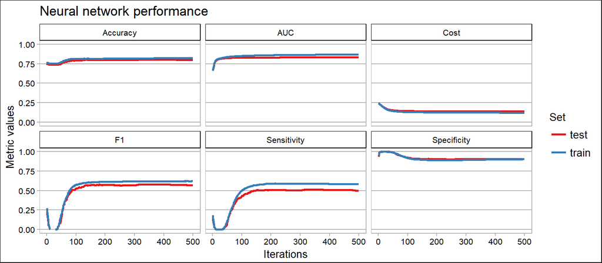

## Modeling (3)

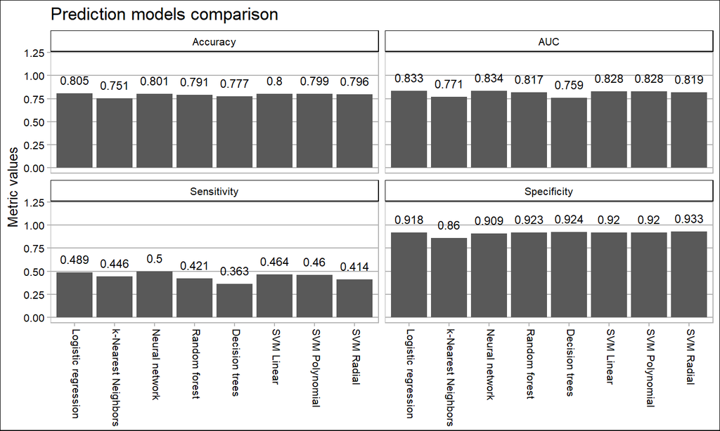

Most important metric is AUC (area under curve), because model with highest AUC value, shows best prediction results while changing probability threshold.

## Conclusion

- Depending on threshold, up to 80%-90 % potential churn cases could be identified.
- Real data results could be slightly worse, because of overfit.
- More data beats better algorithms.
- More info about data collection methods could uncover some data leakages.

### Things to try next:

- More detailed feature selection (drop unusful, add new).
- Unsupervised learning methods (clustering).
- Churn predictions in different groups (service type, contract type, etc.).
- Ensembling different models.

[figure not shown]